# Homework. Basics of statistics

В цьому домашньому завданні відпрацюємо з вами знання, отримані в модулі зі статистики.

**Завдання 1.**

Ми обговорили з Вами на лекції, що велика літера Сігма грецького алфавіту позначає в математиці суму. Знайдіть з використанням Python $\Sigma x$, $\Sigma x^2$, та $\Sigma (x-1)^2$ для наступного набору даних: `1 3 4` Виведіть результат кожного обчислення на екран.

```python
#Сума всіх значень у наборі даних.
set = [1, 3, 4]
sum_x = sum(set)
sum_x2 = sum([x**2 for x in set])
sum_x_minus_1_squared = sum([(x-1) ** 2 for x in set])
print("Σx: ", sum_x)
print("Σx2: ", sum_x2)
print("Σ(x−1)2: ", sum_x_minus_1_squared)
```

```
Σx:  8
Σx2:  26
Σ(x−1)2:  13
```

**Завдання 2.**

Ми зібрали дані про суму покупок в гривнях 20ма випадково обраними клієнтами в нашому магазині (всього клієнтів у нас більше) за минулий місяць. Вони представлені в змінній `sum_purchases`. Знайдіть **вибіркове середнє** для цих даних кожним з зазначених методів:

2.1. без використання жодних бібліотек, користуючись тільки Python.  
2.2. використовуючи відповідний метод бібліотеки `numpy`.

Виведіть результат обчислень в кожному з випадків на екран та порівняйте результати. Вони співпадають?

```python
sum_purchases = [ 316,  493,  367,  153,  224,  121,  322,  450,  196,  397,  281,
  239,  484,  124,  223,  448,  432,  255, 4310, 3524]
```

Обчислимо середне значення з Python:

```python
sample_mean = sum(sum_purchases) / len(sum_purchases)
sample_mean
```

```
667.95
```

Обчислимо середнє значення з NumPy:

```python
np.mean(sum_purchases)
```

```
667.95
```

Відповіді співпадають.

**Завдання 3.**

Для того ж набору даних в змінній `sum_purchases` обчисліть **медіану** кожним з зазначених методів:

3.1. без використання жодних бібліотек, користуючись тільки Python.  
3.2. використовуючи відповідний метод бібліотеки numpy.

Виведіть результат обчислень в кожному з випадків на екран. Порівняйте результати зі значенням вибіркового середнього. Напишіть коментар, для яких задач ви б використовували вибіркове середнє, а для яких - медіану?

1. Сортуємо у порядку зростання:

```python
sorted_purch = sorted(sum_purchases)
print(sorted_purch)
```

```
[121, 124, 153, 196, 223, 224, 239, 255, 281, 316, 322, 367, 397, 432, 448, 450, 484, 493, 3524, 4310]
```

2. Знаходимо довжину списку:

```python
len_purch = len(sorted_purch)
len_purch
```

```
20
```

3. Так як кількість елементів парна, медіану визначаємо як середнє значення двох серединних елементів:

```python
median = (sorted_purch[len_purch//2-1] + sorted_purch[len_purch//2]) / 2
median
```

```
319.0
```

Знайдемо медіану з NumPy:

```python
np.median(sorted_purch)
```

```
319.0
```

Відповіді співпадають.

**Завдання 4**.

Обчислість стандартне відхилення наведеної вибірки в змінній `sum_purchases` кожним з зазначених методів:

4.1. без використання жодних бібліотек, користуючись тільки Python.  
4.2. використовуючи відповідний метод бібліотеки numpy.

Виведіть результат обчислень в кожному з випадків на екран.

1. Обчислюємо квадрат відхилень від середнього:

```python
x_minus_mean = [(x - sample_mean)**2 for x in sum_purchases]
```

2. Обчислюємо стандартне відхилення, так як у нас вибірка, то кількість значень в наборі зменшуємо на одиницю для більг точного результату

```python
std_deviation = np.sqrt(sum(x_minus_mean)/(len(sum_purchases)-1))
std_deviation
```

```
1124.5433447451132
```

3. Знайдемо стандартне відхилення з NumPy:

```python
np.std(sum_purchases, ddof=1)
```

```
1124.5433447451132
```

Відповіді співпадають

**Завдання 5**.

Ми провели дослідження віку студентів-першокурсників. Виявилось, що

- 10 студентів мають вік 16 років
- 25 студентів - 17 років
- 20 студентів - 18 років
- 2 студенти - 20 років

Обчислість середнє значення для цієї вибірки будь-яким способом - на чистому Python або з numpy - та виведіть результат на екран.

**Рішення**  
Для того, щоб обчислити середнє значення віку студентів з цієї вибірки обчислимо загальну суму віку всіх студентів та поділимо на загальну кількість студентів

```python
age_16 = 10
age_17 = 25
age_20 = 2
age_18 = 20

# загальна кількість студентів:
all_students = age_16 + age_17 + age_20 + age_18

# загальна сума віку
age_sum = (age_16 * 16) + (age_17 * 17) + (age_18 * 18) + (age_20*20)

#Обчислимо середнэ значення віку:
mean_age = age_sum / all_students
print("Середній вік: ", mean_age)
```

```
Середній вік:  17.280701754385966
```

**Завдання 6**.

Крім даних про суму покупок, ми зібрали ще дані про кількість відвідувань кожного з кожного покупця, які знаходяться в змінній `visits`. Обчисліть коефіцієнт кореляції Пірсона для суми покупок і кількості відвідувань кожним з зазначених методів:

6.1. без використання жодних бібліотек, користуючись тільки Python.  
6.2. використовуючи відповідний метод бібліотеки numpy.

Виведіть результат на екран. Проаналізуйте результат.

Виведіть додатково графік розсіювання викликавши код нижче і зробіть заключення, чи варто щось змінити при підрахунку кореляції, аби коефіцієнт Пірсона показував коректну оцінку лінійної залежності?

```python
sum_purchases = [ 316,  493,  367,  153,  224,  121,  322,  450,  196,  397,  281, 239,  484,  124,  223,  448,  432,  255, 4310, 3524]
```

```python
visits = [ 6,  2, 10,  3,  9,  9,  2,  3,  6,  6, 10,  2,  5, 10,  3,  5,  4, 7,  4,  2]
col = len(visits)
col
```

```
20
```

```python
# Обчислюємо середнє значення для visits
sample_mean_visits = sum(visits) / len(visits)
sample_mean_visits
```

```
5.4
```

```python
# Обчислюємо квадрат відхилень від середнього для visits
x_minus_mean_visits = [(x - sample_mean_visits)**2 for x in visits]
```

```python
# Обчислюємо стандартне відхилення для visits
std_deviation_visits = np.sqrt(sum(x_minus_mean_visits)/(len(visits)-1))
std_deviation_visits
```

```
2.9091507170885533
```

```python
# Перевіряємо з NumPy
np.std(visits, ddof=1)
```

```
2.9091507170885533
```

```python
#Обчислюємо коваріацію visits & sum_purchases
vis_purch = [ (visits[i] - sample_mean_visits)*(sum_purchases[i] - sample_mean) for i in range(col)]

cov_vis_purch = sum(vis_purch)/(col-1)
cov_vis_purch
```

```
-990.1368421052633
```

```python
np.var(visits, ddof=1)
```

```
8.463157894736844
```

```python
# Перевіряємо з NumPy
np.cov(visits,sum_purchases)
```

```
array([[ 8.46315789e+00, -9.90136842e+02],
       [-9.90136842e+02,  1.26459773e+06]])
```

```python
#Обчислюємо коеф кореляції visits & sum_purchases
cov_vis_purch / (std_deviation_visits * std_deviation)
```

```
-0.30265844687666454
```

```python
# Перевіряємо з NumPy
np.corrcoef(visits,sum_purchases)
```

```
array([[ 1.        , -0.30265845],
       [-0.30265845,  1.        ]])
```

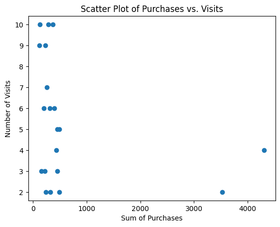

```python
import matplotlib.pyplot as plt

plt.scatter(sum_purchases, visits)
plt.title('Scatter Plot of Purchases vs. Visits')
plt.xlabel('Sum of Purchases')
plt.ylabel('Number of Visits');
```

Коефіцієнт корелярії показує, що є слабка негативна лінійна залежність, та на графіку розсіювання того не видно, через викиди.

**Завдання 7**.

В попередньому завданні ми помітили, що викиди нам заважають отримати "правдиве" значення кореляції. Давайте вилучимо записи, які відповідають значенням з викидами в сумі покупок і обчисліть коеф. кореляції. Для цього поставте `threshold`, який дорінює середньому значенню + 2 стандартних вдіхилля суми покупок і всі значення, які більше за нього, будемо вважати викидами (є і інші правила для визначення викидів - з ним и познайомимось пізніше).

Вилучіть значення з обох масивів і обчисліть коеф. кореляції Пірсона з допомогою `numpy` для кількості візитів і суми покупок без записів-викидів. Виведіть результат на екран, побудуйте діаграму розсіювання і проаналізуйте результат: що можемо сказати про залежність в даних?

```python
threshold = sample_mean + 2 * std_deviation
threshold
```

```
2917.0366894902263
```

```python
# Вилучаємо викиди зі списку сум покупок і відповідні записи зі списку відвідувань
filtered_sum_purchases = []
filtered_visits = []
for i in range(len(sum_purchases)):
    if sum_purchases[i] <= threshold:
        filtered_sum_purchases.append(sum_purchases[i])
        filtered_visits.append(visits[i])
```

```python
print(filtered_sum_purchases)
print(filtered_visits)
```

```
[316, 493, 367, 153, 224, 121, 322, 450, 196, 397, 281, 239, 484, 124, 223, 448, 432, 255]
[6, 2, 10, 3, 9, 9, 2, 3, 6, 6, 10, 2, 5, 10, 3, 5, 4, 7]
```

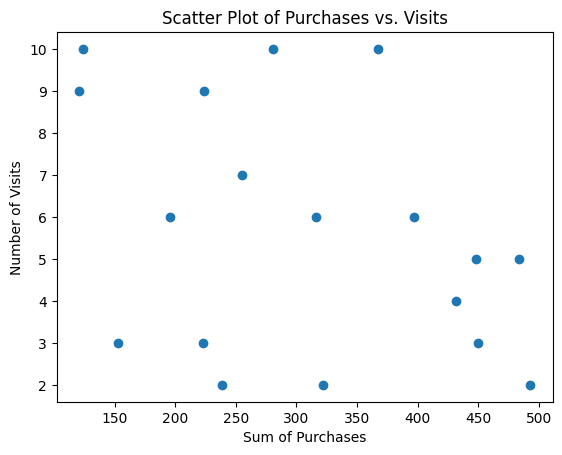

```python
plt.scatter(filtered_sum_purchases, filtered_visits)
plt.title('Scatter Plot of Purchases vs. Visits')
plt.xlabel('Sum of Purchases')
plt.ylabel('Number of Visits');
```

```python
np.corrcoef(filtered_sum_purchases, filtered_visits)
```

```
array([[ 1.        , -0.36852121],
       [-0.36852121,  1.        ]])
```

Без викидів, коефіцієнт кореляції збільшився на 6 сотих. Це досі слабка негативна лінійна залежність, але на графіку вже більш прослідковується. Можна сказати, що коли сума покупок збільшується, то кількість відвідувань зазвичай зменшується, і навпаки, але ця залежність є слабкою